# RFRLFLT January, 2024

2024-01-31

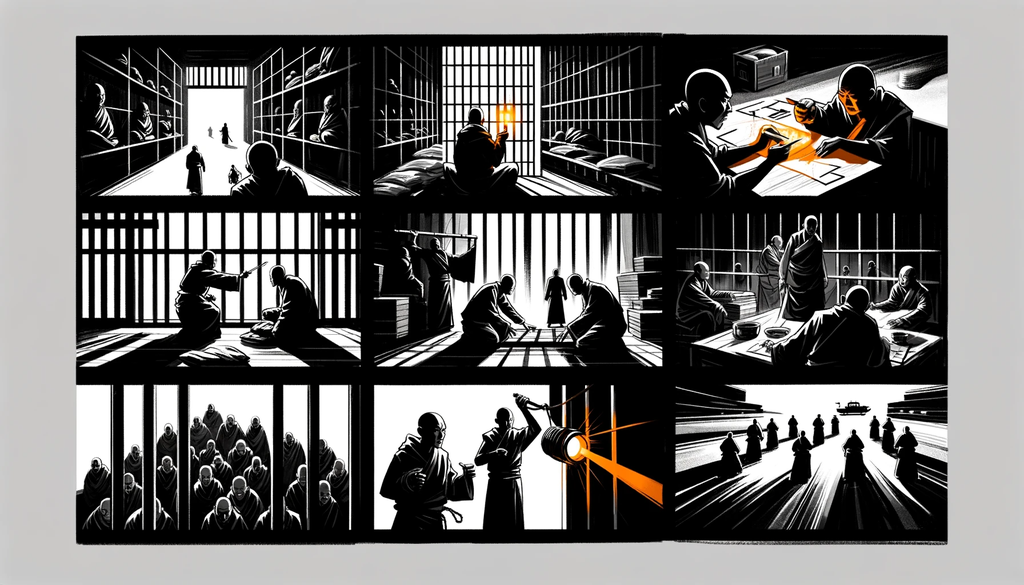

**Prison monks**

New lists and details in this edition. Smaller headers so when I am filling this on the tube people can’t easily see how much reflection is going on here.

##### The prevailing weather:

A luminous sort of gloomy. Refreshing after dark. Barely damp.

##### The song(s):

This Feeling, Alabama Shakes  
Folsom Prison Blues, Johnny Cash  
Shelter from the Storm, Bob Dylan  
Sherab Nyingpo Mantra, Tashi Lhunpo Monks  
Coffin Nails, MF DOOM

[interactive chart not shown]

##### The lyrics quote:

> “I came in from the wilderness, a creature void of form, come in she said I’ll give you, shelter from the storm”

– Bob Dylan

> “…HMMMHMMHMHMHHMMMMMMMHMHMHMHMMHMHMMMMMMMHHHHHHHHHHHHHMMMMMMMMMMMMMMMMMMMMHH…”

– Tashi Lhunpo Monks

> **sweet piano riff**

– MF DOOM

##### The movie/series:

Raiders of the Lost Ark  
Charade  
Paterson  
Poor Things

##### The reflection on media:

Raiders is one of the best desert action adventure epic movies of all times. Many agree. The reasons are too many to count. Spielberg at his best. His buddy Soderbergh, another Steven, edited the movie to remove, all colour and all sound, and posted it online. [Here](https://extension765.com/blogs/soderblog/raiders). You can still understand every single thing that’s going on, characters, intentions, tensions, pace. That’s not film stars or magic, it’s just a guy who knows how to direct. Leaving aside technical mastery of all things cinema. The story of the ark is very cool. The ark is essentially a box of Gods. In this movie, the McGuffin is very much alive.

##### The book(s):

The book is in the book review

##### The reflection on something else:

The McGuffin (McG) is an element of a story that, while in itself not being of any import, drives the story forward. It is the ancient idol sought by the archeologist, the elusive piece of evidence that the detectives needs to close the case.

The McG is extremely useful in story telling, especially in cinema where it can occcupy a space in the viewers mind even if it has been shown only in passing or not at all. I was trying to think of real life McGs in real life, and I was struggling. But I have come up with something. Each of us has a McG inside, in fact we usually have multitudes. I am thinking of the imagined versions of things we hold in our head and let drive our story. In this sense the McG can have positive or negative impacts in our lives and this is unknown while the search is still going on. We must strive to make our McGs mysterious and engaging, they must make us see life as a whole and not divide it into shorter chases, it must not be good or bad and evolution mist be in its nature.

##### The reflection in tweet form:

The McGuffin is alive

##### The joke:

It was an okay start to the year, a little cold but I think it will even out.